# Post 01

### Adding smooth line

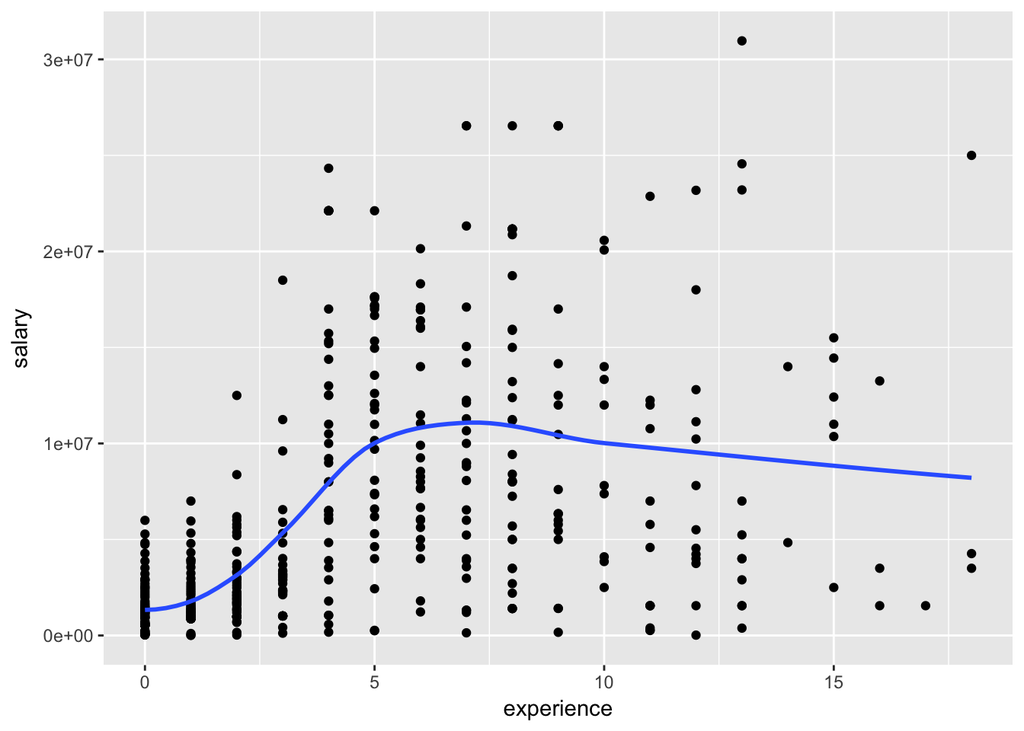

```r
ggplot(data = players, aes(x = experience, y = salary)) + geom_point() + geom_smooth(method= 'loess', se = F)
```

### Jitter Plot

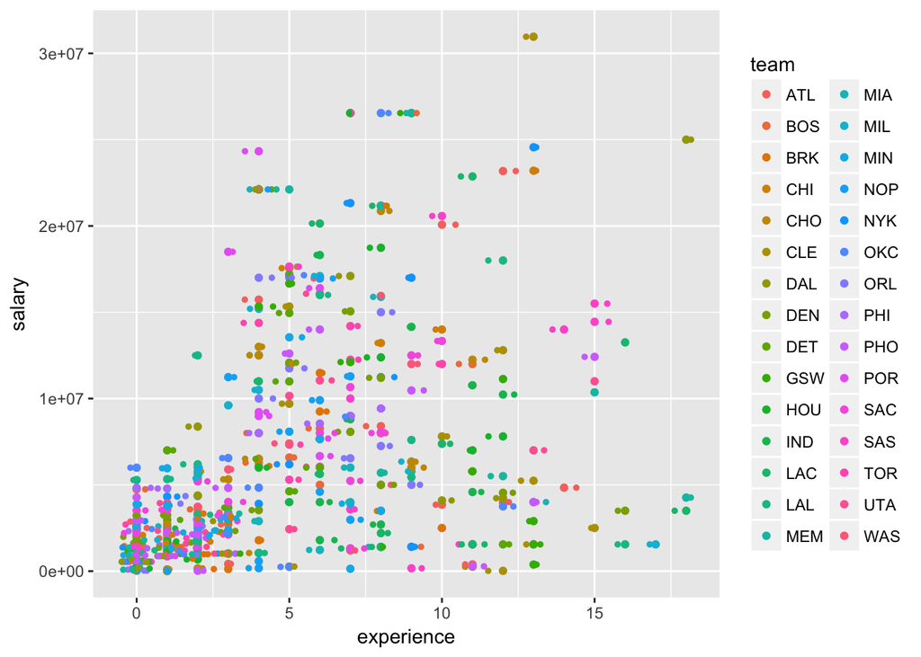

```r
myplot <- myplot + geom_jitter(width = .5, size=1)

myplot
```

### Bubble Plot

While scatterplot lets you compare the relationship between 2 continuous variables, bubble chart serves well if you want to understand relationship within the underlying groups based on:

```
+  A Categorical variable (by changing the color) and
+  Another continuous variable (by changing the size of points).
```

In simpler words, bubble charts are more suitable if you have 4-Dimensional data where two of them are numeric (X and Y) and one other categorical (color) and another numeric variable (size).

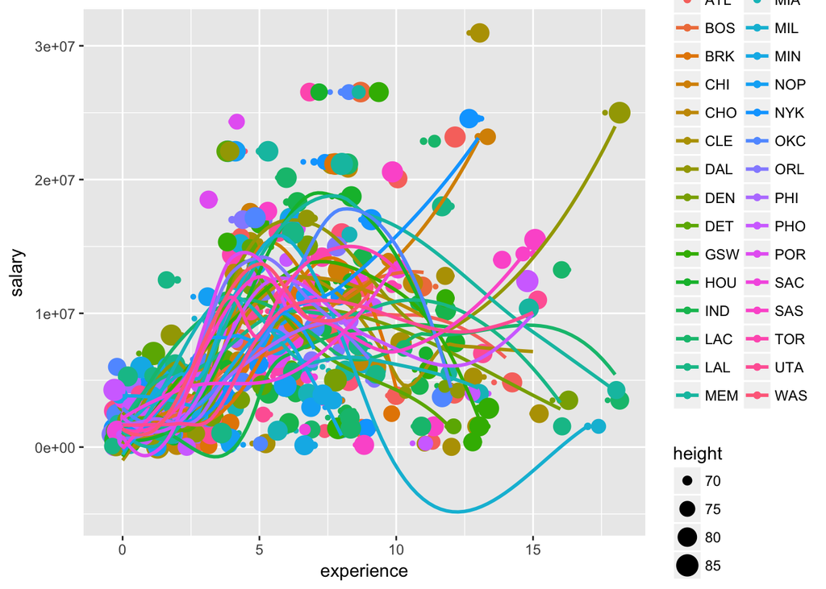

```r
myplot + geom_jitter(aes(col=team, size=height)) +
  geom_smooth(aes(col=team), method="loess", se=F)
```

### Diverging Barplot

Diverging Bars is a bar chart that can handle both negative and positive values. This can be implemented by a smart tweak with geom_bar().

In order to make a bar chart create bars instead of histogram, we need to do two things. 1. Set stat=identity 2. Provide both x and y inside aes() where, x is either character or factor and y is numeric.

In below example, since we only get positive variables, we can only show one-side barplot, but still we can show prensent each team at different colors.

```r
1
```

```
## [1] 1
```

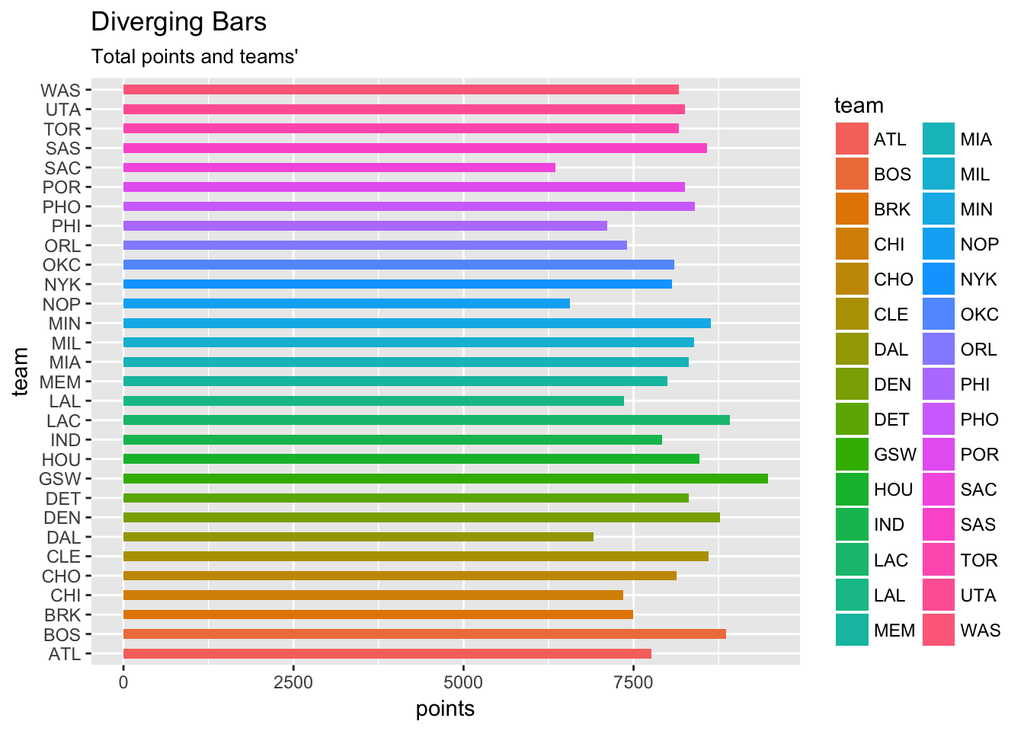

```r
ggplot(players, aes(y= points, x=team, label= team)) +
  geom_bar(stat='identity', aes(fill=team), width=.5)  +
  labs(subtitle="Total points and teams'",
       title= "Diverging Bars") +
  coord_flip()
```

### Diverging Lollipop Chart

Lollipop chart conveys the same information as bar chart and diverging bar. Except that it looks more modern.

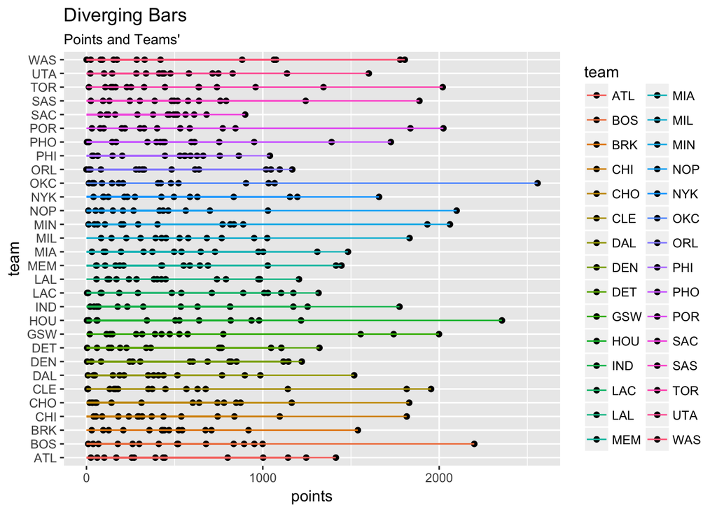

```r
ggplot(players, aes(y= points, x=team, label= team)) +
  geom_point(stat='identity', aes(fill=team), width=.5)   +
  geom_segment(aes(y = 0,
                   x = team,
                   xend = team,
                   yend = points,
               color = team)) +
   labs(subtitle="Points and Teams'",
       title= "Diverging Bars") +
  coord_flip()
```

### Histogram

Histogram on a continuous variable can be accomplished using either geom_bar() or geom_histogram(). When using geom_histogram(), you can control the number of bars using the *bins* or *binwidth* option.

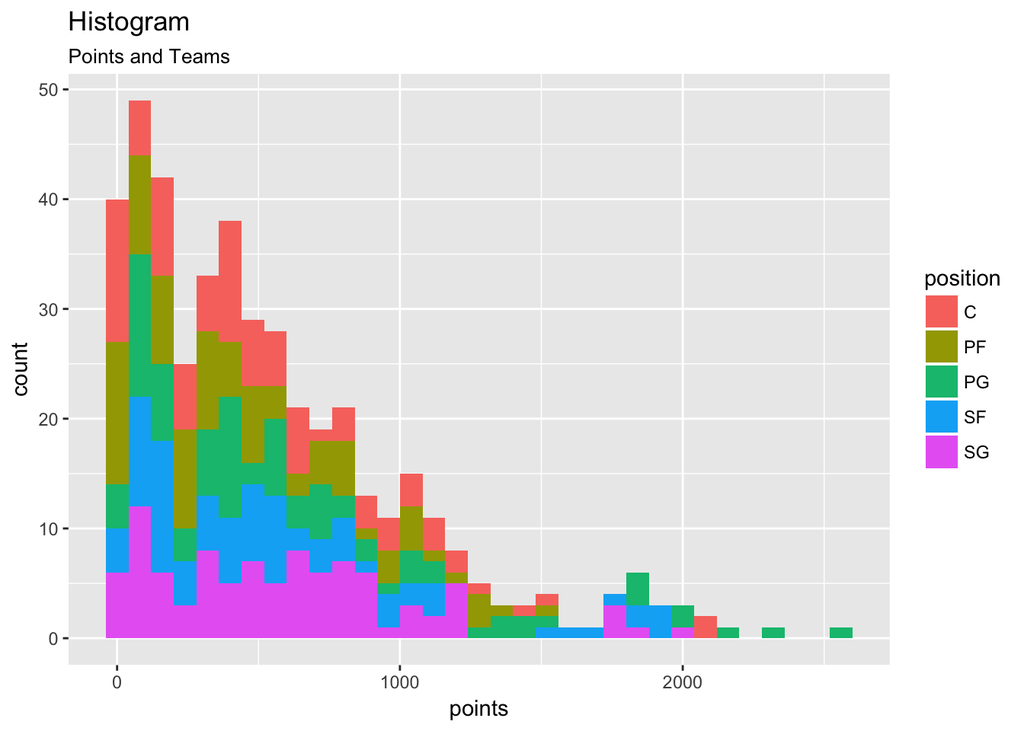

```r
ggplot(players, aes(points)) +
  geom_histogram(aes(fill = position), binwidth = 80) +
  labs(subtitle="Points and Teams",
       title= "Histogram")
```

### Boxplot

Box plot is an excellent tool to study the distribution. It can also show the distributions within multiple groups, along with the median, range and outliers if any.

The dark line inside the box represents the median. The top of box is 75% percentile and bottom of box is 25% percentile. The end points of the lines is at a distance of 1.5*IQR, where IQR or Inter Quartile Range is the distance between 25th and 75th percentiles. The points outside the whiskers are marked as dots and are normally considered as extreme points.

Setting *varwidth=T* adjusts the width of the boxes to be proportional to the number of observation it contains.

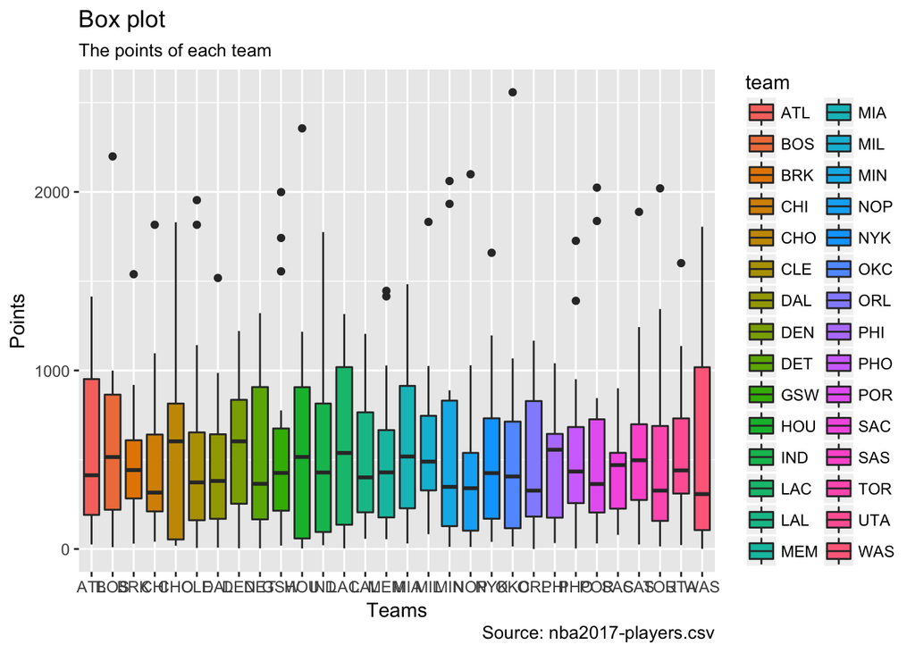

```r
ggplot(players, aes(team, points, fill = team)) +
  geom_boxplot(varwidth=T) +
    labs(title="Box plot",
         subtitle="The points of each team",
         caption="Source: nba2017-players.csv",
         x="Teams",
         y="Points")
```

## Summary

- **Basic Structure**: ggplot(data, aes(x,y)) + geom
- **Adding labels**: ggtitle() labs(title, subtitle, x, y)
- **Adding aesthetics**: aes(color, alpha, linetype)
- **Adding smooth lines**: ggplot + geom_smooth()
- **Jitter plot**: ggplot + geom_jitter()
- **Bubble plot**: geom_smooth() + geom_jitter()
- **Barplot**: geom_bar()
- **Lollipop Chart**: geom_point() + geom_segment()
- **Histogram**: geom_histogram()
- **Boxplot**: geom_boxplot()

## Conclusions

- **Base R graphic**
- Ugly, laborious, and verbose.
- **ggplot**
- Follows a grammar, just like any other languages.
- The grammar defines basic components in a plot.
- Grammar of graphics is originally coined by Lee Wilkinson.
- While R’s traditional graphics offers a nice set of plots, some of them require a lot of work. Viewing the same plot for different groups in our data is particularly difficult.
- In contrast, the ggplot2 package is extremely flexible and repeating plots for groups is quite easy.

# References

1. “Data visualization with R & ggplot2”“, by Karthik Ram. https://github.com/ucb-stat133/stat133-fall-2017/blob/master/slides/14-ggplot-lecture.pdf
2. “The Grammar of Graphics & ggplot2”, by Gaston Sachez. https://docs.google.com/presentation/d/e/2PACX-1vTGKt6asJIPfSXbuO5Jn1qtAOTQbOcWmE0TVXr67z7DOkOUHPj43Vi1Q7hqw-xYTy3pzD2985H9It0T/pub?start=false&loop=false&delayms=3000&slide=id.gd30d76405_0_29
3. The dataset ‘players’, from “nba2017-players.csv” in github. https://github.com/ucb-stat133/stat133-fall-2017/blob/master/data/nba2017-players.csv
4. The ‘ggplot2’ cheatsheet from github. https://github.com/ucb-stat133/stat133-fall-2017/blob/master/cheat-sheets/ggplot2-cheatsheet-2.1.pdf
5. “Lab 5: First contact with dplyr and ggplot2” from github. https://github.com/ucb-stat133/stat133-fall-2017/blob/master/labs/lab05-dplyr-ggplot-basics.md
6. “Lab 6: More dplyr, ggplot2, and files’ stuff” from github. https://github.com/ucb-stat133/stat133-fall-2017/blob/master/labs/lab06-more-dplyr-ggplot.md
7. “Examples using ggplot2” http://r4stats.com/examples/graphics-ggplot2/